# Прогнозирование эффективности восстановление золота из руды

## Подготовка данных

### Структура данных

Рассмотрим структуру представленных для исследования данных.

#### Обучающая выборка

```python
df_train.info()#assign('Nan %'=lambda)
```

```
<class 'pandas.core.frame.DataFrame'>
RangeIndex: 14149 entries, 0 to 14148
Data columns (total 87 columns):
 #   Column                                              Non-Null Count  Dtype
---  ------                                              --------------  -----
 0   date                                                14149 non-null  object
 1   final.output.concentrate_ag                         14148 non-null  float64
 2   final.output.concentrate_pb                         14148 non-null  float64
 3   final.output.concentrate_sol                        13938 non-null  float64
 4   final.output.concentrate_au                         14149 non-null  float64
 5   final.output.recovery                               14149 non-null  float64
 6   final.output.tail_ag                                14149 non-null  float64
 7   final.output.tail_pb                                14049 non-null  float64
 8   final.output.tail_sol                               14144 non-null  float64
 9   final.output.tail_au                                14149 non-null  float64
```

[output cut: 79 more lines]

```python
ser = df_train.isna().sum().sort_values(ascending=False).astype('int')
ser = ser[ser > 0]
pd.DataFrame({'Кол-во пропусков': ser, '% пропусков': round(ser/df_train.shape[0]*100, 2)})
```

|  | Кол-во пропусков | % пропусков |
| --- | --- | --- |
| secondary_cleaner.output.tail_sol | 1605 | 11.34 |
| rougher.state.floatbank10_e_air | 436 | 3.08 |
| rougher.input.floatbank11_xanthate | 428 | 3.02 |
| primary_cleaner.output.concentrate_sol | 286 | 2.02 |
| secondary_cleaner.state.floatbank2_a_air | 217 | 1.53 |
| ... | ... | ... |
| primary_cleaner.output.tail_ag | 1 | 0.01 |
| final.output.concentrate_ag | 1 | 0.01 |
| rougher.calculation.sulfate_to_au_concentrate | 1 | 0.01 |
| rougher.output.tail_ag | 1 | 0.01 |
| final.output.concentrate_pb | 1 | 0.01 |

62 rows × 2 columns

```python
print('Максимальное количество пропусков: {} ({}%)'.format(df_train.isna().sum().max(), int(df_train.isna().sum().max() / len(df_train) * 100)))
```

```
Максимальное количество пропусков: 1605 (11%)
```

Таблица с обучабщей выборкой содержит 14149 строк и 87 столбцов, один из которых (date) имеет строковый тип данных, остальные - вещественный. В большинстве столбцов видим наличие небольшого количества пропусков. Максимальное количество пропусков в столбце secondary_cleaner.output.tail_sol.

#### Тестовая выборка

```python
df_test.info()
```

```
<class 'pandas.core.frame.DataFrame'>
RangeIndex: 5290 entries, 0 to 5289
Data columns (total 53 columns):
 #   Column                                      Non-Null Count  Dtype
---  ------                                      --------------  -----
 0   date                                        5290 non-null   object
 1   primary_cleaner.input.sulfate               5286 non-null   float64
 2   primary_cleaner.input.depressant            5285 non-null   float64
 3   primary_cleaner.input.feed_size             5290 non-null   float64
 4   primary_cleaner.input.xanthate              5286 non-null   float64
 5   primary_cleaner.state.floatbank8_a_air      5290 non-null   float64
 6   primary_cleaner.state.floatbank8_a_level    5290 non-null   float64
 7   primary_cleaner.state.floatbank8_b_air      5290 non-null   float64
 8   primary_cleaner.state.floatbank8_b_level    5290 non-null   float64
 9   primary_cleaner.state.floatbank8_c_air      5290 non-null   float64
```

[output cut: 45 more lines]

Тестовая выборка содержит 5290 записей и 53 столбца (как и в обучающей выборке 1 столбец строковый с датой, остальные - вещественные числа). Пропуски встречаются редко и в небольшом количестве.

```python
set(df_train.columns) - set(df_test.columns)
```

```
{'final.output.concentrate_ag',
 'final.output.concentrate_au',
 'final.output.concentrate_pb',
 'final.output.concentrate_sol',
 'final.output.recovery',
 'final.output.tail_ag',
 'final.output.tail_au',
 'final.output.tail_pb',
 'final.output.tail_sol',
 'primary_cleaner.output.concentrate_ag',
 'primary_cleaner.output.concentrate_au',
 'primary_cleaner.output.concentrate_pb',
 'primary_cleaner.output.concentrate_sol',
 'primary_cleaner.output.tail_ag',
 'primary_cleaner.output.tail_au',
 'primary_cleaner.output.tail_pb',
 'primary_cleaner.output.tail_sol',
 'rougher.calculation.au_pb_ratio',
 'rougher.calculation.floatbank10_sulfate_to_au_feed',
 'rougher.calculation.floatbank11_sulfate_to_au_feed',
 'rougher.calculation.sulfate_to_au_concentrate',
 'rougher.output.concentrate_ag',
 'rougher.output.concentrate_au',
 'rougher.output.concentrate_pb',
 'rougher.output.concentrate_sol',
 'rougher.output.recovery',
 'rougher.output.tail_ag',
 'rougher.output.tail_au',
 'rougher.output.tail_pb',
 'rougher.output.tail_sol',
 'secondary_cleaner.output.tail_ag',
 'secondary_cleaner.output.tail_au',
 'secondary_cleaner.output.tail_pb',
 'secondary_cleaner.output.tail_sol'}
```

В тестовой выборке отсутствуют данные о концентрации веществ в основной фракции и в отвалах на всех стадиях, кроме концентрации веществ в исходной руде, поступающей на вход процесса. Также отсутствуют столбцы с эффективностью очистки.

#### Полный датасет

```python
df_full.info()
```

```
<class 'pandas.core.frame.DataFrame'>
RangeIndex: 19439 entries, 0 to 19438
Data columns (total 87 columns):
 #   Column                                              Non-Null Count  Dtype
---  ------                                              --------------  -----
 0   date                                                19439 non-null  object
 1   final.output.concentrate_ag                         19438 non-null  float64
 2   final.output.concentrate_pb                         19438 non-null  float64
 3   final.output.concentrate_sol                        19228 non-null  float64
 4   final.output.concentrate_au                         19439 non-null  float64
 5   final.output.recovery                               19439 non-null  float64
 6   final.output.tail_ag                                19438 non-null  float64
 7   final.output.tail_pb                                19338 non-null  float64
 8   final.output.tail_sol                               19433 non-null  float64
 9   final.output.tail_au                                19439 non-null  float64
```

[output cut: 79 more lines]

Полный датасет содержит компиляцию обучающей и тестовой выборок. Столбцы, отсутствующие в тестовой выборке, в полном датасете указаны и в значительной степени заполнены.

### Расчет эффективности обогащения

Для обучающей выборки проведем расчет эффективности обогащения на черновой и финальной стадиях.

```python
def recovery(C, F, T):
    if F * (C - T) == 0:
        return 0
    else:
        return C * (F - T) / F / (C - T) * 100

df_train['final.output.recovery_calculated'] = df_train.apply(lambda x: recovery(x['final.output.concentrate_au'], x['rougher.input.feed_au'], x['final.output.tail_au']), axis=1)
df_train['rougher.output.recovery_calculated'] = df_train.apply(lambda x: recovery(x['rougher.output.concentrate_au'], x['rougher.input.feed_au'], x['rougher.output.tail_au']), axis=1)
mae_final = mean_absolute_error(df_train['final.output.recovery'], df_train['final.output.recovery_calculated'])
mae_rougher = mean_absolute_error(df_train['rougher.output.recovery'], df_train['rougher.output.recovery_calculated'])
print(color.BOLD + 'Сравнение вычисленной и данной эффективностей' + color.END)
pd.DataFrame(data={'mean': [df_train['final.output.recovery'].mean(), df_train['rougher.output.recovery'].mean()],
                   'mean (calculated)': [df_train['final.output.recovery_calculated'].mean(), df_train['rougher.output.recovery_calculated'].mean()],
                   'MAE': [mae_final, mae_rougher]}, index=['final', 'rougher'])
```

```
Сравнение вычисленной и данной эффективностей
```

|  | mean | mean (calculated) | MAE |
| --- | --- | --- | --- |
| final | 66.518832 | 66.518832 | 9.197645e-15 |
| rougher | 82.704502 | 82.704502 | 1.074891e-14 |

Видим, что рассчитанная нами эффективность совпадает с данной в датасете.

### Предобработка данных

#### Изменение типов

Изменим тип столбца с датами и временем снятия показаний со строки на datetime. Посмотрим за какие периоды представленны данные в выборках.

```python
df_train['date'] = pd.to_datetime(df_train['date'], format='%Y-%m-%dT%H:%M:%S')
df_test['date'] = pd.to_datetime(df_test['date'], format='%Y-%m-%dT%H:%M:%S')
df_full['date'] = pd.to_datetime(df_full['date'], format='%Y-%m-%dT%H:%M:%S')
print('Обучающая выборка: данные за период {} - {}'.format(df_train.date.min(), df_train.date.max()))
print('Тестовая выборка: данные за период {} - {}'.format(df_test.date.min(), df_test.date.max()))
```

```
Обучающая выборка: данные за период 2016-01-15 00:00:00 - 2018-08-18 10:59:59
Тестовая выборка: данные за период 2016-09-01 00:59:59 - 2017-12-31 23:59:59
```

#### Полнота данных по времени

Исследуем, насколько полно представлены данные в разрезе моментов их получения.

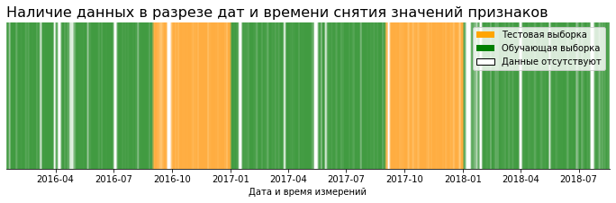

```python
#comment
fig, ax = plt.subplots(1, 1, figsize=(12, 3))
ax.vlines(x=df_train['date'], ymin=0, ymax=df_train.notna().sum(axis=1).apply(lambda x: 1 if x>0 else 0), color='green', alpha=.7, linewidth=0.05)
ax.vlines(x=df_test['date'], ymin=0, ymax=df_test.notna().sum(axis=1).apply(lambda x: 1 if x>0 else 0), color='orange', alpha=.7, linewidth=0.05)
orange_patch = mpatches.Patch(facecolor='orange', label='Тестовая выборка')
green_patch = mpatches.Patch(facecolor='green', label='Обучающая выборка')
white_patch = mpatches.Patch(facecolor='white', edgecolor='black', label='Данные отсутствуют')
plt.legend(handles=[orange_patch, green_patch, white_patch])
ax.set_title('Наличие данных в разрезе дат и времени снятия значений признаков', loc='left', fontdict={'fontsize': 16})
ax.yaxis.set_visible(False)
ax.spines['top'].set_visible(False)
ax.spines['right'].set_visible(False)
ax.spines['left'].set_visible(False)
ax.set_ylim(0, 1)
ax.set_xlim(df_train['date'].min(), df_train['date'].max())
ax.set_xlabel('Дата и время измерений')
plt.show()
```

```python
print('Значения интервалов между показаниями (часы):', sorted(df_train.assign(interval = lambda df: (df['date'] - df['date'].shift(1)).dt.seconds/3600).loc[:, 'interval'].unique()))
```

```
Значения интервалов между показаниями (часы): [nan, 0.0, 1.0, 2.0, 3.0, 4.0, 5.0, 6.0, 6.999722222222222, 7.0, 8.0, 9.0, 10.0, 11.0, 12.0, 13.0, 14.0, 15.0, 16.0, 18.0, 19.0, 20.0, 21.0, 22.0, 23.0]
```

Хотя и есть пропуски от нескольких часов до суток - в целом данные представлены за весь период более менее равномерно.

Рассмотрим пропуски в столбцах, являющихся признаками и целями для последующего обучения модели. Перечень признаков совпадает со столбцами тестового датасета.  
Целевые признаки - это эффективность обогащения на нулевой (флотация) и финальной стадиях.  
Посмотрим на статистику столбцов-признаков в обучающем датасете.

```python
pd.options.display.float_format = "{:,.2f}".format
features_stat_train = df_train.loc[:, df_test.columns].describe().T.join(df_train.isna().sum().rename('NaN')).join((df_train.isna().sum() / len(df_train) * 100).rename('NaN %')).sort_values(by='NaN', ascending=False)
features_stat_train
```

|  | count | mean | std | min | 25% | 50% | 75% | max | NaN | NaN % |
| --- | --- | --- | --- | --- | --- | --- | --- | --- | --- | --- |
| rougher.state.floatbank10_e_air | 13,713.00 | 1,090.21 | 184.61 | -1.97 | 997.18 | 1,050.50 | 1,200.05 | 1,922.64 | 436 | 3.08 |
| rougher.input.floatbank11_xanthate | 13,721.00 | 5.89 | 1.12 | 0.00 | 5.20 | 6.00 | 6.70 | 9.70 | 428 | 3.02 |
| secondary_cleaner.state.floatbank2_a_air | 13,932.00 | 29.61 | 5.80 | 0.08 | 25.10 | 30.03 | 34.89 | 52.65 | 217 | 1.53 |
| rougher.input.feed_size | 14,005.00 | 60.11 | 22.42 | 9.66 | 48.97 | 55.37 | 66.08 | 484.97 | 144 | 1.02 |
| rougher.input.feed_pb | 14,049.00 | 3.52 | 1.07 | 0.01 | 2.78 | 3.42 | 4.23 | 7.14 | 100 | 0.71 |
| primary_cleaner.input.xanthate | 14,049.00 | 0.89 | 0.37 | 0.00 | 0.61 | 0.89 | 1.10 | 2.51 | 100 | 0.71 |
| rougher.input.feed_sol | 14,071.00 | 36.31 | 4.96 | 0.01 | 34.12 | 37.02 | 39.42 | 48.36 | 78 | 0.55 |
| rougher.input.floatbank11_sulfate | 14,113.00 | 11.37 | 3.74 | 0.00 | 9.51 | 11.38 | 13.50 | 37.98 | 36 | 0.25 |
| primary_cleaner.input.depressant | 14,117.00 | 8.87 | 3.36 | 0.00 | 6.04 | 8.04 | 11.52 | 20.05 | 32 | 0.23 |
| rougher.input.floatbank10_sulfate | 14,120.00 | 11.76 | 3.28 | 0.00 | 9.86 | 11.69 | 13.61 | 36.12 | 29 | 0.20 |
| secondary_cleaner.state.floatbank2_b_air | 14,128.00 | 24.91 | 5.99 | 0.00 | 22.05 | 27.02 | 28.94 | 35.15 | 21 | 0.15 |
| primary_cleaner.input.sulfate | 14,129.00 | 133.32 | 39.43 | 0.00 | 107.01 | 133.02 | 159.83 | 250.13 | 20 | 0.14 |
| rougher.input.feed_rate | 14,141.00 | 474.03 | 104.04 | 0.01 | 420.78 | 499.45 | 547.33 | 717.51 | 8 | 0.06 |
| rougher.input.floatbank10_xanthate | 14,141.00 | 5.85 | 1.10 | 0.00 | 5.12 | 5.95 | 6.60 | 9.70 | 8 | 0.06 |
| secondary_cleaner.state.floatbank4_a_air | 14,143.00 | 19.99 | 5.66 | 0.00 | 14.99 | 20.00 | 24.99 | 30.12 | 6 | 0.04 |
| primary_cleaner.state.floatbank8_a_air | 14,145.00 | 1,608.00 | 128.39 | 0.01 | 1,595.70 | 1,601.82 | 1,699.72 | 2,079.53 | 4 | 0.03 |
| primary_cleaner.state.floatbank8_b_air | 14,145.00 | 1,608.61 | 131.11 | 0.01 | 1,558.96 | 1,601.82 | 1,700.22 | 2,114.91 | 4 | 0.03 |
| secondary_cleaner.state.floatbank3_a_air | 14,145.00 | 29.24 | 5.64 | 0.00 | 24.99 | 28.02 | 34.99 | 44.26 | 4 | 0.03 |
| primary_cleaner.state.floatbank8_d_air | 14,146.00 | 1,542.19 | 278.32 | 0.01 | 1,452.68 | 1,600.17 | 1,699.36 | 2,398.90 | 3 | 0.02 |
| secondary_cleaner.state.floatbank6_a_air | 14,147.00 | 19.58 | 5.76 | 0.20 | 14.99 | 19.98 | 24.99 | 32.19 | 2 | 0.01 |
| primary_cleaner.state.floatbank8_c_air | 14,147.00 | 1,608.88 | 134.27 | 0.02 | 1,549.87 | 1,601.57 | 1,700.46 | 2,013.16 | 2 | 0.01 |
| secondary_cleaner.state.floatbank4_b_level | 14,148.00 | -460.23 | 58.84 | -799.89 | -500.15 | -499.39 | -400.04 | -145.07 | 1 | 0.01 |
| secondary_cleaner.state.floatbank5_b_level | 14,148.00 | -483.97 | 39.21 | -800.01 | -500.11 | -499.91 | -453.19 | -157.40 | 1 | 0.01 |
| secondary_cleaner.state.floatbank2_b_level | 14,148.00 | -503.70 | 62.84 | -799.87 | -500.27 | -500.01 | -499.76 | -212.06 | 1 | 0.01 |
| secondary_cleaner.state.floatbank3_a_level | 14,148.00 | -478.24 | 54.66 | -799.61 | -500.18 | -499.88 | -436.92 | -191.68 | 1 | 0.01 |
| secondary_cleaner.state.floatbank4_a_level | 14,148.00 | -478.70 | 50.74 | -799.71 | -500.63 | -499.68 | -477.47 | -245.24 | 1 | 0.01 |
| secondary_cleaner.state.floatbank3_b_air | 14,148.00 | 22.66 | 5.00 | 0.00 | 19.95 | 22.04 | 25.97 | 35.07 | 1 | 0.01 |
| secondary_cleaner.state.floatbank3_b_level | 14,148.00 | -488.92 | 41.93 | -759.18 | -500.11 | -499.97 | -499.76 | -159.74 | 1 | 0.01 |
| secondary_cleaner.state.floatbank5_a_air | 14,148.00 | 16.78 | 5.83 | -0.37 | 11.08 | 17.93 | 21.35 | 43.71 | 1 | 0.01 |
| secondary_cleaner.state.floatbank5_b_air | 14,148.00 | 13.06 | 5.77 | 0.65 | 8.99 | 12.00 | 17.98 | 27.93 | 1 | 0.01 |
| secondary_cleaner.state.floatbank4_b_air | 14,148.00 | 15.49 | 5.26 | 0.00 | 11.89 | 14.98 | 20.06 | 24.01 | 1 | 0.01 |
| secondary_cleaner.state.floatbank5_a_level | 14,148.00 | -483.96 | 37.89 | -797.14 | -500.36 | -499.70 | -487.71 | -275.07 | 1 | 0.01 |
| secondary_cleaner.state.floatbank2_a_level | 14,148.00 | -502.22 | 60.28 | -799.61 | -500.25 | -499.96 | -499.59 | -127.88 | 1 | 0.01 |
| rougher.state.floatbank10_c_air | 14,148.00 | 1,299.36 | 213.40 | -0.04 | 1,103.10 | 1,300.21 | 1,450.35 | 2,499.13 | 1 | 0.01 |
| rougher.state.floatbank10_a_air | 14,148.00 | 1,124.73 | 169.31 | -0.04 | 999.80 | 1,001.69 | 1,299.51 | 1,521.98 | 1 | 0.01 |
| rougher.state.floatbank10_b_air | 14,148.00 | 1,320.71 | 183.16 | -0.65 | 1,199.37 | 1,301.37 | 1,449.55 | 1,809.19 | 1 | 0.01 |
| primary_cleaner.state.floatbank8_a_level | 14,148.00 | -488.78 | 35.70 | -798.64 | -500.29 | -499.91 | -499.38 | -330.13 | 1 | 0.01 |
| primary_cleaner.state.floatbank8_b_level | 14,148.00 | -489.17 | 33.60 | -740.12 | -500.38 | -499.94 | -499.39 | -347.35 | 1 | 0.01 |
| primary_cleaner.state.floatbank8_c_level | 14,148.00 | -489.61 | 35.62 | -799.80 | -500.60 | -499.87 | -498.80 | -346.65 | 1 | 0.01 |
| primary_cleaner.state.floatbank8_d_level | 14,148.00 | -483.46 | 47.10 | -799.79 | -500.46 | -499.83 | -498.48 | -30.60 | 1 | 0.01 |
| rougher.state.floatbank10_a_level | 14,148.00 | -369.46 | 93.95 | -650.20 | -499.79 | -300.18 | -299.96 | -281.04 | 1 | 0.01 |
| secondary_cleaner.state.floatbank6_a_level | 14,148.00 | -506.80 | 37.08 | -809.40 | -500.75 | -500.06 | -499.54 | -104.43 | 1 | 0.01 |
| rougher.state.floatbank10_b_level | 14,148.00 | -464.26 | 57.40 | -650.26 | -500.18 | -499.76 | -400.43 | -296.38 | 1 | 0.01 |
| rougher.state.floatbank10_c_level | 14,148.00 | -465.05 | 55.90 | -641.00 | -500.21 | -499.68 | -400.66 | -292.16 | 1 | 0.01 |
| rougher.state.floatbank10_f_air | 14,149.00 | 1,035.49 | 175.05 | -2.43 | 900.97 | 1,000.05 | 1,100.17 | 1,706.31 | 0 | 0.00 |
| rougher.input.feed_au | 14,149.00 | 7.87 | 1.92 | 0.01 | 6.60 | 7.65 | 9.07 | 13.13 | 0 | 0.00 |
| rougher.input.feed_ag | 14,149.00 | 8.58 | 1.90 | 0.01 | 7.13 | 8.16 | 9.92 | 14.60 | 0 | 0.00 |
| rougher.state.floatbank10_d_air | 14,149.00 | 1,210.34 | 210.43 | -0.55 | 1,059.71 | 1,200.74 | 1,344.38 | 1,817.20 | 0 | 0.00 |
| rougher.state.floatbank10_d_level | 14,149.00 | -465.46 | 55.77 | -640.52 | -500.36 | -499.47 | -401.05 | -208.33 | 0 | 0.00 |
| rougher.state.floatbank10_e_level | 14,149.00 | -464.92 | 56.60 | -649.44 | -500.25 | -499.61 | -400.60 | -272.20 | 0 | 0.00 |
| primary_cleaner.input.feed_size | 14,149.00 | 7.32 | 0.61 | 1.08 | 6.96 | 7.29 | 7.70 | 10.47 | 0 | 0.00 |
| rougher.state.floatbank10_f_level | 14,149.00 | -464.69 | 56.65 | -649.88 | -500.48 | -499.36 | -401.01 | -191.72 | 0 | 0.00 |

Видим относительно небольшое количество пропусков (около 3% для двух признаков, для остальных существенно меньше).  
Для поиска аномалий необходимо существенно более глубокое погружение в технологический процесс обогащения, и мы этого делать не будем. Констатируем лишь, что минимальные значения признаков, отвечающих за концентрации и размер гранул, не отрицательны (что, очевидно, не имело бы смысла).

#### Заполнение пропусков

Заполнять пропуски будем значениями с предыдущего временного слоя, предполагая, что значения показателей меняются во времени достаточно медленно (об этом сказано в техническом задании заказчика).

```python
df_train = df_train.fillna(method='ffill')
df_full = df_full.fillna(method='ffill')
```

```python
print('Количество пропусков в обучающем датасете: ', df_train.isna().sum().sum())
print('Количество пропусков в полном датасете: ', df_full.isna().sum().sum())
```

```
Количество пропусков в обучающем датасете:  0
Количество пропусков в полном датасете:  0
```

#### Поиск пропусков и аномалий в целевых признаках

Смотрим количество пропусков в целевых признаках в обучающем датасете.

```python
target_columns = ['final.output.concentrate_au', 'rougher.output.concentrate_au', 'final.output.tail_au', 'rougher.output.recovery']
features_stat_train = df_train.loc[:, target_columns].describe().T.join(df_train.isna().sum().rename('NaN')).join((df_train.isna().sum() / len(df_train) * 100).rename('NaN %'))
features_stat_train
```

|  | count | mean | std | min | 25% | 50% | 75% | max | NaN | NaN % |
| --- | --- | --- | --- | --- | --- | --- | --- | --- | --- | --- |
| final.output.concentrate_au | 14,149.00 | 44.00 | 4.91 | 0.00 | 43.28 | 44.87 | 46.17 | 52.76 | 0 | 0.00 |
| rougher.output.concentrate_au | 14,149.00 | 19.44 | 3.77 | 0.00 | 18.43 | 19.95 | 21.39 | 28.15 | 0 | 0.00 |
| final.output.tail_au | 14,149.00 | 2.92 | 0.90 | 0.00 | 2.37 | 2.85 | 3.43 | 8.20 | 0 | 0.00 |
| rougher.output.recovery | 14,149.00 | 82.70 | 14.48 | 0.00 | 79.99 | 85.30 | 90.17 | 100.00 | 0 | 0.00 |

Пропусков нет.  
Теперь ищем пропуски в целевых столбцах полного датасета.

```python
features_stat_train = df_full.loc[:, target_columns].describe().T.join(df_train.isna().sum().rename('NaN')).join((df_train.isna().sum() / len(df_train) * 100).rename('NaN %'))
features_stat_train
```

|  | count | mean | std | min | 25% | 50% | 75% | max | NaN | NaN % |
| --- | --- | --- | --- | --- | --- | --- | --- | --- | --- | --- |
| final.output.concentrate_au | 19,439.00 | 44.08 | 5.13 | 0.00 | 43.40 | 45.01 | 46.28 | 52.76 | 0 | 0.00 |
| rougher.output.concentrate_au | 19,439.00 | 19.77 | 3.75 | 0.00 | 18.80 | 20.28 | 21.72 | 28.82 | 0 | 0.00 |
| final.output.tail_au | 19,439.00 | 3.04 | 0.92 | 0.00 | 2.46 | 2.98 | 3.57 | 8.25 | 0 | 0.00 |
| rougher.output.recovery | 19,439.00 | 83.33 | 14.15 | 0.00 | 81.04 | 86.19 | 90.01 | 100.00 | 0 | 0.00 |

Тоже все ок, пропусков нет.

## Анализ данных

Перейдем к анализу данных и для начала подготовим наборы столбцов, которые понадобятся нам в дальнейшем.

```python
features_columns = df_test.columns.tolist()
features_columns.remove('date')
```

```python
recovery_columns = ['rougher.output.recovery', 'final.output.recovery']
#concentrate_columns = [col for col in df_train.columns if col.find('output.concentrate') >= 0]
concentrate_columns_au = ['rougher.input.feed_au', 'rougher.output.concentrate_au', 'primary_cleaner.output.concentrate_au', 'final.output.concentrate_au']
tail_columns_au = ['rougher.output.tail_au', 'primary_cleaner.output.tail_au', 'secondary_cleaner.output.tail_au', 'final.output.tail_au']
concentrate_columns_ag = ['rougher.input.feed_ag', 'rougher.output.concentrate_ag', 'primary_cleaner.output.concentrate_ag', 'final.output.concentrate_ag']
tail_columns_ag = ['rougher.output.tail_ag', 'primary_cleaner.output.tail_ag', 'secondary_cleaner.output.tail_ag', 'final.output.tail_ag']
concentrate_columns_pb = ['rougher.input.feed_pb', 'rougher.output.concentrate_pb', 'primary_cleaner.output.concentrate_pb', 'final.output.concentrate_pb']
tail_columns_pb = ['rougher.output.tail_pb', 'primary_cleaner.output.tail_pb', 'secondary_cleaner.output.tail_pb', 'final.output.tail_pb']
concentrate_columns_sol = ['rougher.input.feed_sol', 'rougher.output.concentrate_sol', 'primary_cleaner.output.concentrate_sol', 'final.output.concentrate_sol']
tail_columns_sol = ['rougher.output.tail_sol', 'primary_cleaner.output.tail_sol', 'secondary_cleaner.output.tail_sol', 'final.output.tail_sol']

input_concentrate_columns = ['rougher.input.feed_ag', 'rougher.input.feed_pb', 'rougher.input.feed_sol', 'rougher.input.feed_au']
rougher_concentrate_columns = ['rougher.output.concentrate_ag', 'rougher.output.concentrate_pb', 'rougher.output.concentrate_sol', 'rougher.output.concentrate_au']
rougher_tail_columns = ['rougher.output.tail_ag', 'rougher.output.tail_pb', 'rougher.output.tail_sol', 'rougher.output.tail_au']
primery_concentrate_columns = ['primary_cleaner.output.concentrate_ag', 'primary_cleaner.output.concentrate_pb', 'primary_cleaner.output.concentrate_sol', 'primary_cleaner.output.concentrate_au']
primery_tail_columns = ['primary_cleaner.output.tail_ag', 'primary_cleaner.output.tail_pb', 'primary_cleaner.output.tail_sol', 'primary_cleaner.output.tail_au']
secondary_tail_columns = ['secondary_cleaner.output.tail_ag', 'secondary_cleaner.output.tail_pb', 'secondary_cleaner.output.tail_sol', 'secondary_cleaner.output.tail_au']
final_concentrate_columns = ['final.output.concentrate_ag', 'final.output.concentrate_pb', 'final.output.concentrate_sol', 'final.output.concentrate_au']
final_tail_columns = ['final.output.tail_ag', 'final.output.tail_pb', 'final.output.tail_sol', 'final.output.tail_au']

stage_columns = {'input_concentrate': ['rougher.input.feed_ag', 'rougher.input.feed_pb', 'rougher.input.feed_sol', 'rougher.input.feed_au'],
                 'rougher_concentrate': ['rougher.output.concentrate_ag', 'rougher.output.concentrate_pb', 'rougher.output.concentrate_sol', 'rougher.output.concentrate_au'],
                 'rougher_tail': ['rougher.output.tail_ag', 'rougher.output.tail_pb', 'rougher.output.tail_sol', 'rougher.output.tail_au'],
                 'primery_concentrate': ['primary_cleaner.output.concentrate_ag', 'primary_cleaner.output.concentrate_pb', 'primary_cleaner.output.concentrate_sol', 'primary_cleaner.output.concentrate_au'],
                 'primery_tail': ['primary_cleaner.output.tail_ag', 'primary_cleaner.output.tail_pb', 'primary_cleaner.output.tail_sol', 'primary_cleaner.output.tail_au'],
                 'secondary_tail': ['secondary_cleaner.output.tail_ag', 'secondary_cleaner.output.tail_pb', 'secondary_cleaner.output.tail_sol', 'secondary_cleaner.output.tail_au'],
                 'final_concentrate': ['final.output.concentrate_ag', 'final.output.concentrate_pb', 'final.output.concentrate_sol', 'final.output.concentrate_au'],
                 'final_tail': ['final.output.tail_ag', 'final.output.tail_pb', 'final.output.tail_sol', 'final.output.tail_au']}
total_concentrate_columns = ['input_concentrate', 'rougher_concentrate', 'primery_concentrate', 'final_concentrate']
total_tail_columns = ['rougher_tail', 'primery_tail', 'secondary_tail', 'final_tail']
rougher_columns = [col for col in features_columns if col.find('rougher') >= 0]
```

### Концентрация золота на разных стадиях

Посмотрим на долю золота в концентрате и отвалах на разных стадиях обогащения, воспользовавшись данными из обучающей выборки.

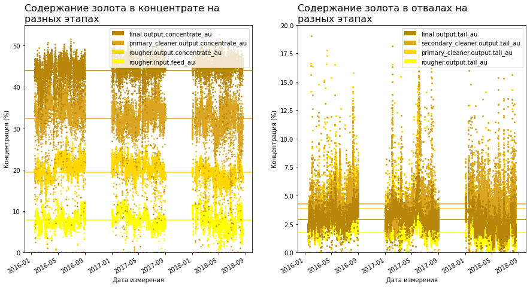

```python
#comment
date_begin = df_train['date'].min() + datetime.timedelta(days=-45)
date_end = df_train['date'].max() + datetime.timedelta(days=45)
fig, ax = plt.subplots(1, 2, figsize=(15, 7))
colors = ['blue', 'orange', 'green', 'red', 'yellow', 'grey']
lbs = [0] * len(concentrate_columns_au)
for i, col in enumerate(concentrate_columns_au):
    ax[0].plot(df_train['date'], df_train[col], marker=".", linestyle='', ms=3, color=colors_stgs_au[i])
    ax[0].plot([date_begin, date_end], [df_train[col].mean()] * 2, marker="", linestyle='-', ms=7, color=colors_stgs_au[i])
    lbs[i] = mpatches.Patch(facecolor=colors_stgs_au[i], label=col)
ax[0].legend(handles=lbs[::-1], loc="upper right")
ax[0].set_title('Содержание золота в концентрате на\nразных этапах', loc='left', fontdict={'fontsize': 16})
ax[0].set_xlabel('Дата измерения')
ax[0].set_ylabel('Концентрация (%)')
ax[0].set_ylim(0, 55)
ax[0].set_xlim(date_begin, date_end)
for label in ax[0].get_xticklabels(which='major'):
    label.set(rotation=30, horizontalalignment='right')

lbs1 = [0] * len(tail_columns_au)
for i, col in enumerate(tail_columns_au):
    ax[1].plot(df_train['date'], df_train[col], marker=".", linestyle='', ms=4, color=colors_stgs_au[i])
    ax[1].plot([date_begin, date_end], [df_train[col].mean()] * 2, marker="", linestyle='-', ms=7, color=colors_stgs_au[i])
    lbs1[i] = mpatches.Patch(facecolor=colors_stgs_au[i], label=col)
ax[1].set_ylim(0, 20)
ax[1].set_xlim(date_begin, date_end)
ax[1].legend(handles=lbs1[::-1], loc="upper right")
ax[1].set_title('Содержание золота в отвалах на\nразных этапах', loc='left', fontdict={'fontsize': 16})
for label in ax[1].get_xticklabels(which='major'):
    label.set(rotation=30, horizontalalignment='right')
ax[1].set_xlabel('Дата измерения')
ax[1].set_ylabel('Концентрация (%)')
plt.show()
```

И более подробно за первый месяц из датасета.

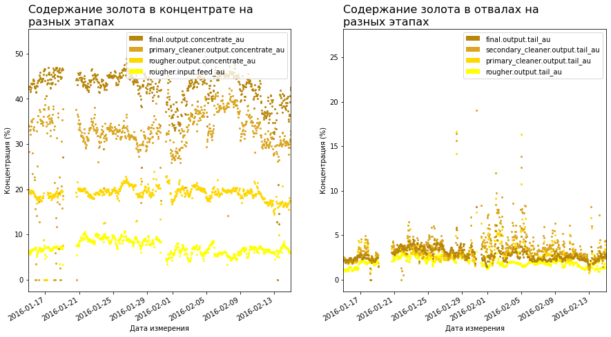

```python
#comment
fig, ax = plt.subplots(1, 2, figsize=(15, 7))
columns_au = [concentrate_columns_au, tail_columns_au]
for j in range(2):
    l = [0] * len(columns_au[j])
    for i, col in enumerate(columns_au[j]):
        l[i], = ax[j].plot(df_train['date'], df_train[col], ".", ls='', ms=4, color=colors_stgs_au[i], label=col)
    ax[j].set_xlim(datetime.datetime.strptime('2016-01-15 00:00:00', '%Y-%m-%d %H:%M:%S'), datetime.datetime.strptime('2016-02-15 00:00:00', '%Y-%m-%d %H:%M:%S'))
    ax[j].legend(handles=l[::-1], loc="upper right")
    for label in ax[j].get_xticklabels(which='major'):
        label.set(rotation=30, horizontalalignment='right')
ax[0].legend(handles=lbs[::-1], loc="upper right")
ax[1].legend(handles=lbs1[::-1], loc="upper right")
ax[0].set_title('Содержание золота в концентрате на\nразных этапах', loc='left', fontdict={'fontsize': 16})
ax[1].set_title('Содержание золота в отвалах на\nразных этапах', loc='left', fontdict={'fontsize': 16})
ax[0].set_xlabel('Дата измерения')
ax[0].set_ylabel('Концентрация (%)')
ax[1].set_xlabel('Дата измерения')
ax[1].set_ylabel('Концентрация (%)')

plt.show()
```

Теперь построим распределение доли золота в концентрате и отвалах на всех стадиях.

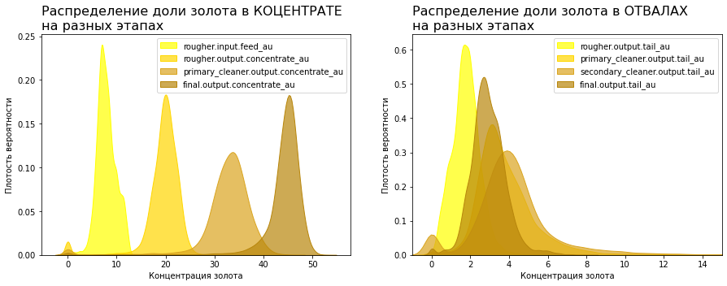

```python
#comment
fig, ax = plt.subplots(1, 2, figsize=(15, 5))
columns_au = [concentrate_columns_au, tail_columns_au]
for j in range(2):
    l = [0] * len(columns_au[j])
    for i, col in enumerate(columns_au[j]):
        sns.kdeplot(df_train[col], shade=True, color=colors_stgs_au[i], label=col, alpha=.7, ax=ax[j])
    ax[j].legend(loc="upper right")
    ax[j].set_xlabel('Концентрация золота')
    ax[j].set_ylabel('Плотость вероятности')
ax[1].set_xlim(-1,15)
ax[0].set_title('Распределение доли золота в КОЦЕНТРАТЕ\nна разных этапах', loc='left', fontdict={'fontsize': 16})
ax[1].set_title('Распределение доли золота в ОТВАЛАХ\nна разных этапах', loc='left', fontdict={'fontsize': 16})
plt.show()
```

Всё вполне ожидаемо: содержание золота в концентрате возрастает по мере очистки. Видим наличие второго пика (пусть и маленького) в нуле. Вполне возможно, что нулевые значения тоже следовало бы заменить на смежные по времени, как мы это делали для пропусков. Однако, мы оставим данные в этой части как есть. В целом, все распределения имеют вид, близкий к нормальному.

### Концентрация серебра и свинца

Аналогично, посмотрим на долю серебра и свинца в концентрате и отвалах на разных стадиях обогащения, воспользовавшись данными из обучающей выборки.

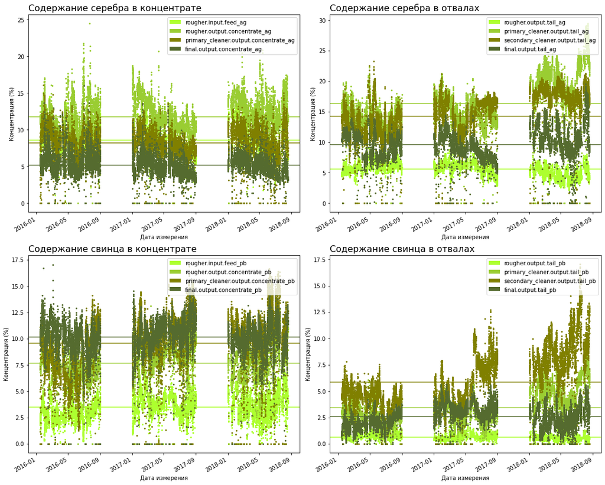

```python
#comment
fig, axs = plt.subplots(2, 2, constrained_layout=True, figsize=(15, 12))
columns_list = [concentrate_columns_ag, tail_columns_ag, concentrate_columns_pb, tail_columns_pb]
color_list = [colors_stgs, colors_stgs, colors_stgs, colors_stgs]
ax = [axs[i][j] for i in range(2) for j in range(2)]
lbs = [[0] * 4] * 4
for j, colors in enumerate(color_list):
    l = [0] * len(columns_list[j])
    for i, col in enumerate(columns_list[j]):
        ax[j].plot(df_train['date'], df_train[col], marker=".", linestyle='', ms=4, color=colors[i], label=col)
        ax[j].plot([date_begin, date_end], [df_train[col].mean()] * 2, marker="", linestyle='-', ms=7, color=colors[i])
        lbs[j][i] = mpatches.Patch(facecolor=colors[i], label=col)
    ax[j].legend(handles=lbs[j], loc="upper right")
    ax[j].set_xlim(date_begin, date_end)
    for label in ax[j].get_xticklabels(which='major'):
        label.set(rotation=30, horizontalalignment='right')
ax[0].set_title('Содержание серебра в концентрате', loc='left', fontdict={'fontsize': 16})
ax[1].set_title('Содержание серебра в отвалах', loc='left', fontdict={'fontsize': 16})
ax[2].set_title('Содержание свинца в концентрате', loc='left', fontdict={'fontsize': 16})
ax[3].set_title('Содержание свинца в отвалах', loc='left', fontdict={'fontsize': 16})
for i in range(4):
    ax[i].set_xlabel('Дата измерения')
    ax[i].set_ylabel('Концентрация (%)')
plt.show()
```

Как и в случае с золотом, наблюдаем большой разброс значений концентрации и серебра, и свинца на всех стадиях обогащения. В среднем содержание серебра в концентрате уменьшается, а свинца увеличивается.

### Средняя концентрация веществ на разных стадиях

Посмотрим теперь отдельно на изменение средних концентраций всех веществ в ходе процесса очистки.

Сначала добавим в обучающую выборку столбцы с суммарной концентрацией всех контролируемых веществ для каждой стадии очистки. Потом построим графики, показывающие как меняется концентрация каждого компонента и суммарная концентрация всех компонентов в ходе процесса обогащения.

```python
#comment
for key in stage_columns:
    df_train[key] = df_train[stage_columns[key]].sum(axis=1)

def series_to_dataframe(series, indexes, column):
    return pd.DataFrame(data=series.tolist(), index=indexes, columns=column)

indexes=['input', 'rougher', 'primary', 'final']
concentrate_table = pd.concat([series_to_dataframe(df_train[concentrate_columns_ag].mean(), indexes, ['Ag']),
                               series_to_dataframe(df_train[concentrate_columns_pb].mean(), indexes, ['Pb']),
                               series_to_dataframe(df_train[concentrate_columns_sol].mean(), indexes, ['Sol']),
                               series_to_dataframe(df_train[concentrate_columns_au].mean(), indexes, ['Au']),
                               series_to_dataframe(df_train[total_concentrate_columns].mean(), indexes, ['Total'])], axis=1)
indexes=['rougher', 'primary', 'secondary', 'final']
tail_table = pd.concat([series_to_dataframe(df_train[tail_columns_ag].mean(), indexes, ['Ag']),
                               series_to_dataframe(df_train[tail_columns_pb].mean(), indexes, ['Pb']),
                               series_to_dataframe(df_train[tail_columns_sol].mean(), indexes, ['Sol']),
                               series_to_dataframe(df_train[tail_columns_au].mean(), indexes, ['Au']),
                               series_to_dataframe(df_train[total_tail_columns].mean(), indexes, ['Total'])], axis=1)
c_styler = concentrate_table.style.set_table_attributes("style='display:inline'").set_caption('Среднее содержание основных веществ в КОНЦЕНТРАТЕ')
t_styler = tail_table.style.set_table_attributes("style='display:inline'").set_caption('Среднее содержание основных веществ в ОТВАЛАХ')

display_html(c_styler._repr_html_() + "\xa0\xa0\xa0" + t_styler._repr_html_(), raw=True)
```

Среднее содержание основных веществ в КОНЦЕНТРАТЕ

|  | Ag | Pb | Sol | Au | Total |
| --- | --- | --- | --- | --- | --- |
| input | 8.579195 | 3.505465 | 36.290933 | 7.866577 | 56.242170 |
| rougher | 11.775812 | 7.664555 | 28.292820 | 19.439958 | 67.173145 |
| primary | 8.200916 | 9.568544 | 10.016250 | 32.386836 | 60.172546 |
| final | 5.141921 | 10.132848 | 9.109311 | 44.003792 | 68.387872 |

Среднее содержание основных веществ в ОТВАЛАХ

|  | Ag | Pb | Sol | Au | Total |
| --- | --- | --- | --- | --- | --- |
| rougher | 5.567238 | 0.653277 | 17.882853 | 1.757473 | 25.860840 |
| primary | 16.303752 | 3.440612 | 7.522594 | 3.839637 | 31.106595 |
| secondary | 14.281516 | 5.846963 | 6.267120 | 4.246961 | 30.642561 |
| final | 9.607035 | 2.583179 | 10.510889 | 2.918421 | 25.619524 |

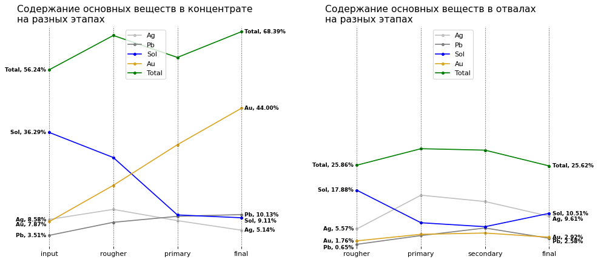

```python
#comment
fig, ax = plt.subplots(1, 2, figsize=(15,6), dpi= 80)
tables = [concentrate_table, tail_table]
for j, table in enumerate(tables):
    l = [0] * len(table.columns)
    for i, col in enumerate(table.columns):
        l[i], = ax[j].plot(table.index, table[col], ".", ls='-', ms=7, color=colors_subs[i], label=col)
    for i in range(len(table)):
        ax[j].vlines(x=i, ymin=-10, ymax=70, color='black', alpha=0.7, linewidth=1, linestyles='dotted')
    ax[j].set_xlim(-0.5, 3.5)
    ax[j].set_ylim(0, 70)
    ax[j].yaxis.set_ticks([])
    [ax[j].spines[where].set_visible(False) for where in ['top', 'right', 'left', 'bottom']]
    ax[j].legend(handles=l, loc="upper center")
for col in concentrate_table.columns:
    concentrate = concentrate_table.loc['input', col]
    concentrate1 = concentrate_table.loc['final', col]
    ax[0].text(-0.05,  concentrate-1 if col == 'Au' else concentrate, '{}, {:.2f}%'.format(col, concentrate), horizontalalignment='right', verticalalignment='center', fontdict={'size':8, 'weight':700})
    ax[0].text(3+0.05,  concentrate1-1 if col == 'Sol' else concentrate1, '{}, {:.2f}%'.format(col, concentrate1), horizontalalignment='left', verticalalignment='center', fontdict={'size':8, 'weight':700})
for col in tail_table.columns:
    concentrate = tail_table.loc['rougher', col]
    concentrate1 = tail_table.loc['final', col]
    ax[1].text(-0.05,  concentrate-1 if col == 'Pb' else concentrate, '{}, {:.2f}%'.format(col, concentrate), horizontalalignment='right', verticalalignment='center', fontdict={'size':8, 'weight':700})
    ax[1].text(3+0.05,  concentrate1-1 if col == 'Ag' or col == 'Pb' else concentrate1, '{}, {:.2f}%'.format(col, concentrate1), horizontalalignment='left', verticalalignment='center', fontdict={'size':8, 'weight':700})
ax[0].set_title('Содержание основных веществ в концентрате\nна разных этапах', loc='left', fontdict={'fontsize': 14})
ax[1].set_title('Содержание основных веществ в отвалах\nна разных этапах', loc='left', fontdict={'fontsize': 14})
plt.show()
```

Добавим данные о концентрации прочих (не контролируемых) компонентов смеси и построим круговые диаграммы, показывающие средний состав смеси на входе и на выходе процесса обогащения.

```python
concentrate_table['Other'] = 100 - concentrate_table['Total']
```

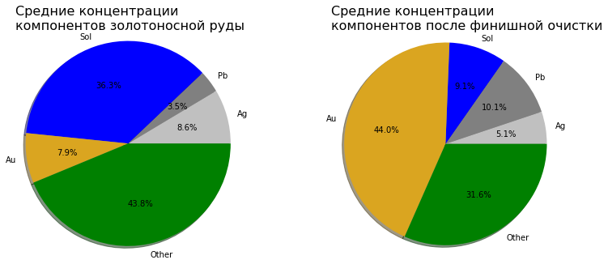

```python
#comment
fig, ax = plt.subplots(1, 2, figsize=(12, 5))
fig.subplots_adjust(wspace=0.4)
axs = [ax[i] for i in range(2)]
axs[0].set_title('Средние концентрации\nкомпонентов золотоносной руды', loc='left', fontdict={'fontsize': 16})
axs[0].pie(concentrate_table.loc['input', ['Ag', 'Pb', 'Sol', 'Au', 'Other']].tolist(), labels=concentrate_table.loc[:, ['Ag', 'Pb', 'Sol', 'Au', 'Other']].columns, colors=colors_subs, shadow=True, autopct='%1.1f%%', startangle=0)
axs[1].set_title('Средние концентрации\nкомпонентов после финишной очистки', loc='left', fontdict={'fontsize': 16})
axs[1].pie(concentrate_table.loc['final', ['Ag', 'Pb', 'Sol', 'Au', 'Other']].tolist(), labels=concentrate_table.loc[:, ['Ag', 'Pb', 'Sol', 'Au', 'Other']].columns, colors=colors_subs, shadow=True, autopct='%1.1f%%', startangle=0)
axs[0].axis('equal')
axs[1].axis('equal')
plt.show()
```

### Распределение размеров гранул

Исследуем как распределены размеры гранул в обучающей и тестовой выборках.

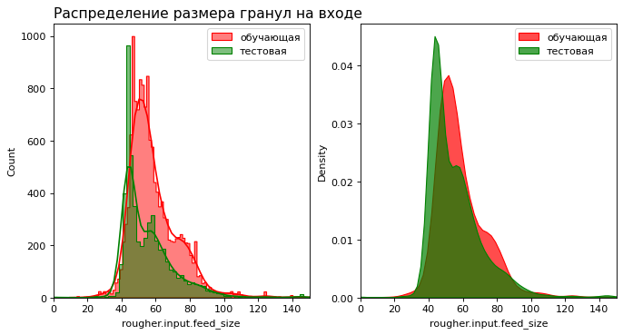

```python
#comment
fig, ax = plt.subplots(1, 2, figsize=(10,5), dpi= 80)
sns.histplot(df_train['rougher.input.feed_size'], kde=True, cbar_kws={'alpha':.7}, element="step", ax=ax[0], color='red', label='обучающая')
sns.histplot(df_test['rougher.input.feed_size'], kde=True, cbar_kws={'alpha':.7}, element="step", ax=ax[0], color='green', label='тестовая')
ax[0].legend()
ax[0].set_xlim(0,150)
sns.kdeplot(df_train['rougher.input.feed_size'], shade=True, color="red", label="обучающая", alpha=.7, ax=ax[1])
sns.kdeplot(df_test['rougher.input.feed_size'], shade=True, color="green", label="тестовая", alpha=.7, ax=ax[1])
ax[1].legend()
ax[1].set_xlim(0,150)
ax[0].set_title('Распределение размера гранул на входе', loc='left', fontdict={'fontsize': 14})
plt.show()
```

```python
pd.concat([df_train['rougher.input.feed_size'].describe().rename('обучающая'), df_test['rougher.input.feed_size'].describe().rename('тестовая')], axis=1)
```

|  | обучающая | тестовая |
| --- | --- | --- |
| count | 14,149.00 | 5,289.00 |
| mean | 60.24 | 55.95 |
| std | 23.01 | 19.08 |
| min | 9.66 | 0.05 |
| 25% | 48.97 | 43.91 |
| 50% | 55.27 | 50.84 |
| 75% | 66.01 | 62.43 |
| max | 484.97 | 392.49 |

Видим большое расхождение в распределении размера гранул в обучающей и тестовой выборках. Даже визуально можно сделать вывод о том, что размеры гранул в этих выборках распределены по разному. Проверим гипотезу, что средние размеры гранул в обучающей и тестовой выборках совпадают. Уровень значимости примем равным 0.01, альтернативная гипотеза - средний размер гранул в обучающей выборке больше.

```python
result = st.ttest_ind(df_train['rougher.input.feed_size'].tolist(), df_test.dropna()['rougher.input.feed_size'].tolist(), equal_var=False)
print('P-value:', result.pvalue)
```

```
P-value: 6.236914218591931e-41
```

Гипотезу о равенстве средних размеров гранул в тестовой и обучающей выборках отвергаем.  
Чтобы понять, как такое могло получиться, построим график, на котором отразим размер гранул на входе в разное время. Выделим зеленым даты из обучающей выборки, а оранжевым - из тестовой.

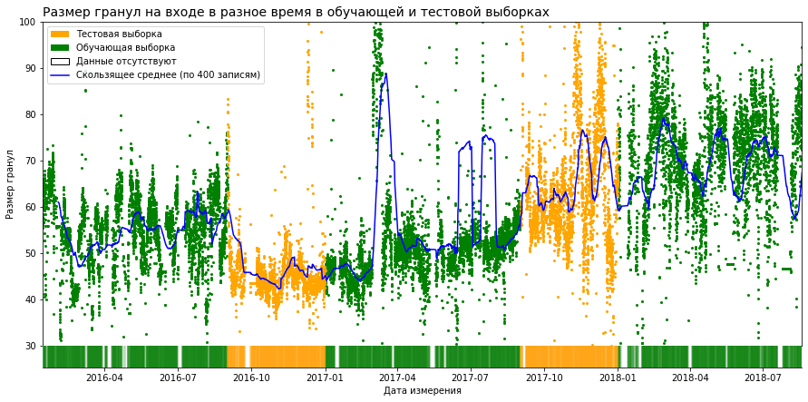

```python
#comment
fig, ax = plt.subplots(2, 1, figsize=(15, 7), gridspec_kw={'height_ratios': [15, 1]})
ax[0].plot(df_train['date'], df_train['rougher.input.feed_size'], ".", ls='', ms=4, color='green', label='размер гранул')
ax[0].plot(df_test['date'], df_test['rougher.input.feed_size'], ".", ls='', ms=4, color='orange', label='размер гранул')
ls, = ax[0].plot(df_full['date'], df_full.loc[:, ['date', 'rougher.input.feed_size']].rolling(400, on='date').mean()['rougher.input.feed_size'], marker="", linestyle='-', ms=4, color='blue', label='Cкользящее среднее (по 400 записям)')
orange_patch = mpatches.Patch(facecolor='orange', label='Тестовая выборка')
green_patch = mpatches.Patch(facecolor='green', label='Обучающая выборка')
white_patch = mpatches.Patch(facecolor='white', edgecolor='black', label='Данные отсутствуют')

ax[1].vlines(x=df_train['date'], ymin=0, ymax=df_train.notna().sum(axis=1).apply(lambda x: 1 if x>0 else 0), color='green', alpha=.7, linewidth=0.1)
ax[1].vlines(x=df_test['date'], ymin=0, ymax=df_test.notna().sum(axis=1).apply(lambda x: 1 if x>0 else 0), color='orange', alpha=.7, linewidth=0.1)
fig.subplots_adjust(hspace=0)
ax[0].set_title('Размер гранул на входе в разное время в обучающей и тестовой выборках', loc='left', fontdict={'fontsize': 14})
ax[1].yaxis.set_visible(False)
ax[0].xaxis.set_visible(False)
ax[1].spines['top'].set_visible(False)
ax[1].spines['right'].set_visible(False)
ax[1].spines['left'].set_visible(False)
ax[1].set_ylim(0, 1)
ax[1].set_xlim(df_train['date'].min(), df_train['date'].max())
ax[0].set_xlim(df_train['date'].min(), df_train['date'].max())
ax[0].set_ylim(30, 100)
ax[0].legend(handles=[orange_patch, green_patch, white_patch, ls])
ax[1].set_xlabel('Дата измерения')
ax[0].set_ylabel('Размер гранул')

plt.show()
```

Причина расхождений стала более понятной: размер гранул может варьироваться в широких пределах, причем промежутки времени с меньшим и большим средним размером гранул могут чередоваться. Как видим, часть тестовой выборки была вырезана в то время, когда размер гранул достаточно долго был аномально мал. Соответственно, в обучающей выборке эти данные наоборот отсутствуют.

### Распределение остальных признаков

Можно предположить, что и остальные признаки в обучающей и тестовой выборках будут иметь визуально различимые отличия в распределениях. Проверим это, построив соответствующие графики.

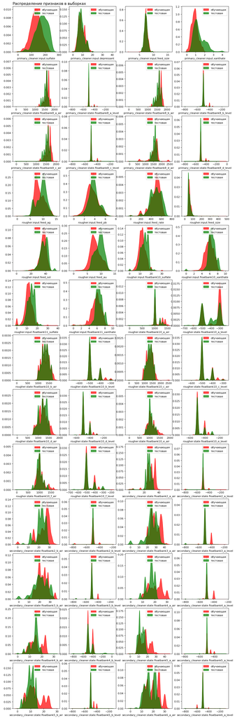

```python
#comment
fig, ax = plt.subplots(13, 4, figsize=(15,50), dpi= 80)
axs = [ax[i][j] for i in range(13) for j in range(4)]
for i, col in enumerate(features_columns):
    sns.kdeplot(df_train[col], shade=True, color="red", label="обучающая", alpha=.7, ax=axs[i])
    sns.kdeplot(df_test[col], shade=True, color="green", label="тестовая", alpha=.7, ax=axs[i])
    axs[i].legend()
    axs[i].set_ylabel("")
ax[0][0].set_title('Распределение признаков в выборках', loc='left', fontdict={'fontsize': 14})
plt.show()
```

Для большинства признаков наблюдаем картину, схожую с распределением размера гранул: распределение признака в обучающей выборке отличается от распределения этого же признака в тестовой выборке. Таким образом, мы должны учитывать этот факт, и вполне можем предположить, что это расхождение скажется в дальнейшем на результатах предсказаний.  
Напоследок проверим распределения целевых признаков в обучающей и тестовой выборках и убедимся, что они также будут отличными.

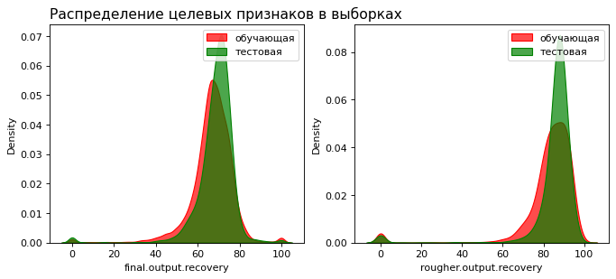

```python
#comment
target_test = df_full.loc[df_full['date'].isin(df_test['date'].tolist()), recovery_columns]
fig, ax = plt.subplots(1, 2, figsize=(10,4), dpi= 80)
sns.kdeplot(df_train['final.output.recovery'], shade=True, color="red", label="обучающая", alpha=.7, ax=ax[0])
sns.kdeplot(target_test['final.output.recovery'], shade=True, color="green", label="тестовая", alpha=.7, ax=ax[0])
ax[0].legend()
sns.kdeplot(df_train['rougher.output.recovery'], shade=True, color="red", label="обучающая", alpha=.7, ax=ax[1])
sns.kdeplot(target_test['rougher.output.recovery'], shade=True, color="green", label="тестовая", alpha=.7, ax=ax[1])
ax[1].legend()
ax[0].set_title('Распределение целевых признаков в выборках', loc='left', fontdict={'fontsize': 14})
plt.show()
```

Средние значения целевых признаков в обучающей и тестовой выборках различаются статистически значимо, о чем нам говорят результаты Т-теста.

```python
for i, col in enumerate(recovery_columns):
    result = st.ttest_ind(df_train[col].to_numpy(), target_test[recovery_columns[i]].to_numpy())
    print('P-value ({}): {}'.format('начальная стадия' if i ==0 else 'финальная стадия', result.pvalue))
```

```
P-value (начальная стадия): 7.429853341358224e-24
P-value (финальная стадия): 4.132556559865079e-33
```

## Модель

### Подготовка выборок

#### Обучающая и тестовая выборки

Разделим обучающую выборку на таблицу с признаками и таблицу с целями. Значения целевых признаков для тестовой выборки возьмем из полного датасета. Пропуски в теством датасете удалим, поскольку их немного.

```python
features = df_train.loc[:, features_columns]
target = df_train.loc[:, recovery_columns]
```

```python
print('Количество строк с пропусками в тестовой выборке: {} ({:.1f}%)'.format(df_test.isna().sum(axis=1).sum(), df_test.isna().sum(axis=1).sum() / len(df_test) * 100))
```

```
Количество строк с пропусками в тестовой выборке: 90 (1.7%)
```

```python
df_test.dropna(inplace=True)
features_test = df_test.loc[:, features_columns]
target_test = df_full.loc[df_full['date'].isin(df_test['date'].tolist()), recovery_columns]
```

#### Нормализация признаков

Нормализуем все признаки, используя MinMaxScaler (распределение многих признаков, как мы видели в разделе 3.5, далеко от нормального. Напомним, что все признаки в обучающей выборке численные.

```python
columns_minmax = features_columns
pd.options.mode.chained_assignment = None
features_tables = [features_test, features]
scaler_minmax = MinMaxScaler()
scaler_minmax.fit(features[columns_minmax])
for df in features_tables:
    df[columns_minmax] = scaler_minmax.transform(df[columns_minmax])
```

### Подготовка метрики

Определим функции для расчета sMAPE и взвешенной sMAPE_w. Создадим из взвешенной sMAPE_w метрику для последующего обучения моделей.

```python
def sMAPE(target, predicted):
    return (abs(target - predicted) / (target + predicted) * 2).sum() / len(predicted) * 100

def sMAPE_w(target, predicted):
    target = pd.DataFrame(target).reset_index(drop=True)
    predicted = pd.DataFrame(predicted)
    predicted.columns = target.columns
    sums = target + predicted
    sums = sums.where(sums != 0, 1)
    smapes = (2 * abs(target - predicted) / sums).sum() / sums.shape[0] * 100
    return 0.25 * smapes[0] + 0.75 * smapes[1]

scorer_wsMAPE = make_scorer(sMAPE_w, greater_is_better=False)
```

### Линейная регрессия

Сначала рассмотрим модель линейной регрессии. Проверим её качество с помощью кросс-валидации. Ограничимся пятью блоками. В качестве функции оценки возьмем взвешенную sMAPE, созданную выше.

```python
model = LinearRegression()
scores = cross_val_score(model, features, target, cv=5, scoring=scorer_wsMAPE)
score = sum(abs(scores)) / len(scores)
print('Линейная регрессия: sMAPE_weighted={:.4f}%'.format(score))
```

```
Линейная регрессия: sMAPE_weighted=12.3846%
```

### Дерево

Аналогичным образом исследуем модель дерева решений. Для подбора гиперпараметров воспользуемся случайным поиском, количество блоков кросс-валидации оставим таким же, равным 5.

```python
tree = DecisionTreeRegressor()

param_dist = {'max_depth': sp_randint(1, 100),
              'splitter': ['best', 'random'],
              'min_samples_split': sp_randint(2, 22),
              'min_samples_leaf': sp_randint(1, 21),
              'random_state': [RANDOM_STATE]}
n_iter_search = 30
random_search = RandomizedSearchCV(tree, param_distributions=param_dist, scoring=scorer_wsMAPE,
                                   n_iter=n_iter_search, cv=5, verbose=1)
random_search.fit(features, target)
best_params_tree = random_search.best_params_
print('Лучшая оценка для дерева решений:', abs(random_search.best_score_))
print('При следующих значениях гиперпараметров:\n', best_params_tree)
```

```
Fitting 5 folds for each of 30 candidates, totalling 150 fits
Лучшая оценка для дерева решений: 10.746911918678027
При следующих значениях гиперпараметров:
 {'max_depth': 6, 'min_samples_leaf': 17, 'min_samples_split': 18, 'random_state': 1234, 'splitter': 'random'}
```

### Случайный лес

И, наконец, посмотрим, какие результаты покажет модель случайного леса.

```python
rgf = RandomForestRegressor()

param_dist = {'n_estimators': sp_randint(1, 150),
              'max_depth': [None],
              'max_features': sp_randint(1, 22),
              'min_samples_split': sp_randint(2, 21),
              'min_samples_leaf': sp_randint(2, 21),
              'bootstrap': [True, False],
              'random_state': [RANDOM_STATE]}
n_iter_search = 30
random_search = RandomizedSearchCV(rgf, param_distributions=param_dist, scoring=scorer_wsMAPE,
                                   n_iter=n_iter_search, cv=5, verbose=1)
random_search.fit(features, target)
best_params_rgf = random_search.best_params_
print('Лучшая оценка для случайного леса:', abs(random_search.best_score_))
print('При следующих значениях гиперпараметров:\n', best_params_rgf)
```

```
Fitting 5 folds for each of 30 candidates, totalling 150 fits
Лучшая оценка для случайного леса: 10.072841298786958
При следующих значениях гиперпараметров:
 {'bootstrap': True, 'max_depth': None, 'max_features': 4, 'min_samples_leaf': 14, 'min_samples_split': 14, 'n_estimators': 139, 'random_state': 1234}
```

### Проверка на тестовой выборке

Итак, лучший результат показала модель случайного леса. Далее работать будем с ней. Проверим модель на тестовой выборке.

```python
model = RandomForestRegressor(bootstrap=best_params_rgf['bootstrap'],
                              max_depth=best_params_rgf['max_depth'],
                              max_features=best_params_rgf['max_features'],
                              min_samples_leaf=best_params_rgf['min_samples_leaf'],
                              min_samples_split=best_params_rgf['min_samples_split'],
                              n_estimators=best_params_rgf['n_estimators'],
                              random_state=RANDOM_STATE)
model.fit(features, target)
predicted = model.predict(features_test)
scores = sMAPE(target_test, predicted)
print('Случайный лес на тестовой выборке: sMAPE_weighted={:.4f}%'.format(0.25 * scores[0] + 0.75 * scores[1]))
```

```
Случайный лес на тестовой выборке: sMAPE_weighted=9.0938%
```

Чтобы понять, насколько модель хороша, сравним её с константным предсказанием средними значениями.

```python
print('Константное предсказание на тестовой выборке: sMAPE_weighted={:.4f}%'.format(sMAPE_w(target_test, target.mean().to_numpy() * np.ones((target_test.shape[0], 2)))))
```

```
Константное предсказание на тестовой выборке: sMAPE_weighted=9.8755%
```

Ну что же - наша модель показывает результат, не сильно отличающийся от предсказания на основе средних значений.

Посмотрим на распределение целевого признака и предсказаний модели для разных этапов очистки (флотация и финальная очистка).

```python
#comment
predicted = pd.DataFrame(predicted)
df = pd.concat([target_test[recovery_columns[0]].describe().rename('цель (флотация)'),
                predicted[0].rename('модель (флотация)').describe(),
                target_test[recovery_columns[1]].describe().rename('цель (финал)'),
                predicted[1].rename('модель (финал)').describe()], axis=1)
pd.concat([df, pd.DataFrame(data=[['-', scores[0], '-', scores[1]]], columns=df.columns, index=['sMAPE'])], axis=0)
```

|  | цель (флотация) | модель (флотация) | цель (финал) | модель (финал) |
| --- | --- | --- | --- | --- |
| count | 5,229.00 | 5,229.00 | 5,229.00 | 5,229.00 |
| mean | 85.13 | 82.64 | 68.66 | 66.62 |
| std | 12.93 | 2.91 | 8.84 | 2.90 |
| min | 0.00 | 68.88 | 0.00 | 49.38 |
| 25% | 84.62 | 80.93 | 65.60 | 64.75 |
| 50% | 87.42 | 82.82 | 69.86 | 67.10 |
| 75% | 89.75 | 84.35 | 73.29 | 68.68 |
| max | 99.17 | 91.08 | 100.00 | 73.83 |
| sMAPE | - | 9.70 | - | 8.89 |

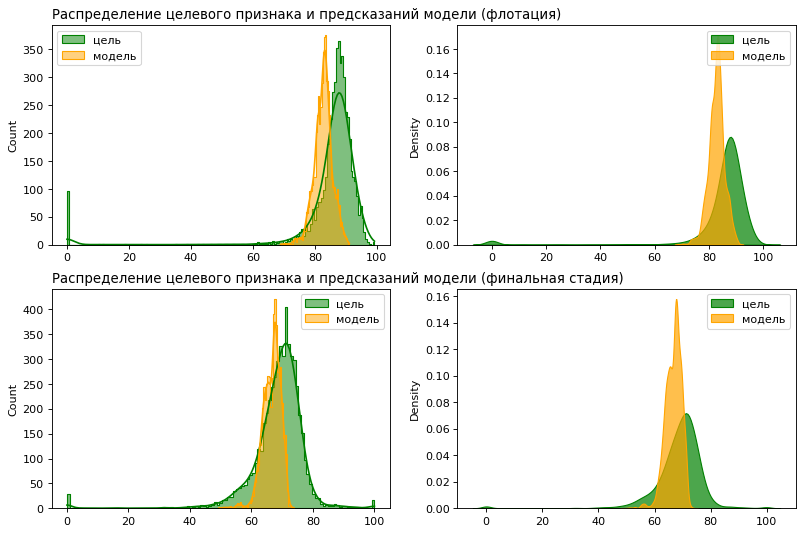

```python
#comment
fig, ax = plt.subplots(2, 2, figsize=(12, 8), dpi= 80)
for i, col in enumerate(recovery_columns):
    sns.histplot(target_test[col], kde=True, cbar_kws={'alpha':.7}, element="step", ax=ax[i][0], color='green', label='цель')
    sns.histplot(predicted[i], kde=True, cbar_kws={'alpha':.7}, element="step", ax=ax[i][0], color='orange', label='модель')
    ax[i][0].legend()
    ax[i][0].set_xlabel("")
    ax[i][0].set_title('Распределение целевого признака и предсказаний модели ({})'.format('флотация' if i == 0 else 'финальная стадия'), loc='left')
    sns.kdeplot(target_test[col], shade=True, color="green", label="цель", alpha=.7, ax=ax[i][1])
    sns.kdeplot(predicted[i], shade=True, color="orange", label="модель", alpha=.7, ax=ax[i][1])
    ax[i][1].legend()
    ax[i][1].set_xlabel("")
plt.show()
```

Проверим гипотезы, что средние значения эффективности на начальной и финальной сталиях обогащения, равны соответствующим средним значениям целевых признаков из тестовой выборки (уровень значимости примем равным 0.01).

```python
for i, col in enumerate(recovery_columns):
    result = st.ttest_ind(target_test[recovery_columns[i]].to_numpy(), predicted[i].to_numpy())
    print('P-value ({}): {}'.format('начальная стадия' if i ==0 else 'финальная стадия', result.pvalue))
```

```
P-value (начальная стадия): 9.450719716371793e-42
P-value (финальная стадия): 6.494240442321961e-56
```

Видим, что наши гипотезы неверны.Средние значеиния целевого признака и предсказаний статистически различны.

## Выводы

Целью настоящего исследования являлось построение прототипа модели машинного обучения, которая должна предсказать коэффициент восстановления золота из золотосодержащей руды. Для анализа использовались данные с параметрами добычи и очистки.

Были исследованы три модели машнного обучения: линейная регрессия, дерево решений и случайный лес. В качестве метрик для каждой стадии (флотация и финальная очистка) использовалась sMAPE (symmetric mean absolute percentage error), в качестве финальной метрики использовалась взвешенная sMAPE с весами 0.25 и 0.75 для флотационной и финальной стадий соответственно.

Лучший результат 10.07 показала модель случайного леса. Далее эта модель была проверена на тестовой выборке (результат 9.09). Сравнение распределений целевых признаков в тестовой выборке с предсказанными моделью показывает посредственное совпадение. Модель предсказывает средние эффективности на обеих стадиях очистки (флотационная и финальная) немного лучше модели, основанной на предсказаниях средними значениями эффективностей в обучающей выборке (9.88).

Вероятно, качество предсказаний модели можно значительно улучшить, разрешив обозначенные проблемы с выбросами, нулевыми значениями и более корректным формированием обучающей и тестовой выборок.